# Benchmarking short-read splicing classification against long-read ground truth

Author

Benjamin Fair

Published

August 25, 2026

## What this notebook does

It rebuilds the key figures of the simulation benchmark, reading **only** the small plot-ready files in `output/` — so it runs in seconds and needs none of the pipeline’s intermediates.

Almost everything here descends from one table, `output/master_confusion_table.tsv.gz` (78 KB), which the Snakemake workflow reduces from roughly 350 GB of alignments and clustering output. That table is shipped with the project, so the figures reproduce without running anything.

**Note**

The workflow reproduces the shipped table *closely but not exactly*, because it calls a newer leafcutter2 than the one that produced the published classifications. The differences are measured in FOOTNOTES.md; every metric’s median change is zero.

## The benchmark, for a new reader

**The problem.** A splicing classifier has to decide, for each splice junction seen in short-read RNA-seq, whether it belongs to a productive transcript or an unproductive one (destined for nonsense-mediated decay). This is easy when the junction is annotated and hard when it isn’t — and unannotated junctions are exactly where unproductive splicing hides. So a benchmark needs ground truth for junctions that no annotation contains, which an annotation-derived truth set cannot provide.

**The trick.** Simulate the short reads from **real full-length long-read cDNAs**. Each of the 334,430 long reads was translated and classified productive/unproductive by NMDFinderB *from the full-length molecule*, independent of any annotation. Short reads are then simulated from those same molecules. So every junction — annotated or not — carries a truth label, and the classifier’s job is to recover it from fragments.

**What is varied.** Four axes, crossed:

| Axis | Levels |
| --- | --- |
| Sequencing depth | 7, from 20 GB (~100 M read pairs) down to 1/64 of that |
| 3’ coverage bias | 5 `Beta(alpha, 1)` fragment-bias conditions, uniform → extreme (a proxy for degraded RNA / low RIN) |
| Annotation given to the classifier | comprehensive Gencode; minimal (MANE); minimal but with complete ORF ends (MinOrfEnds) |
| Classification method | 4, below |

**The four methods.** Two annotation baselines and two readings of leafcutter2:

| Method | Rule |
| --- | --- |
| `Annotations` | believe the GTF; **decline to call** anything unannotated |
| `Assume unannotated is UP` | believe the GTF; call anything unannotated unproductive |
| `Leaf2 junction_classifier` | leafcutter2’s raw `Coding` flag alone — an intermediate signal, taken without annotation or UTR context. Never declines. |
| `Leaf2 multi-flag` | leafcutter2’s actual final `PR`/`UP`/`NE` verdict — the label the tool appends to intron names in its clustered output |

The last two are not “the tool” versus “a custom rule”: they are the tool’s internal coding flag versus the tool’s published classification. Comparing them measures what leafcutter2’s consolidation logic buys over the bare flag.

**Junction subclasses.** Every junction carries three bits, `GencodePC:Annot:UTR` — is it in a Gencode protein-coding transcript, is it annotated at all, does it lie in a UTR. These are always assigned from *comprehensive Gencode*, even when scoring the MANE or MinOrfEnds runs, so a subclass means the same thing in every panel. `0:0:*` is the interesting corner: junctions no annotation knows about.

## The master confusion table

```python
from pathlib import Path

import matplotlib as mpl
import matplotlib.pyplot as plt
import numpy as np
import pandas as pd
from IPython.display import display
from matplotlib.colors import LogNorm
from mpl_toolkits.axes_grid1.inset_locator import inset_axes
from plotnine import (
    aes, annotate, coord_cartesian, element_rect, element_text, geom_abline,
    geom_hline, geom_point, ggplot, labs, scale_color_manual,
    scale_size_continuous, scale_x_continuous, scale_y_continuous, theme,
    theme_classic,
)

PROJECT = Path.cwd().resolve()
if PROJECT.name == "analysis":
    PROJECT = PROJECT.parent
OUTPUT = PROJECT / "output"

MM = 1 / 25.4

SUBCLASS_LEVELS = ["0:0:0", "0:0:1", "0:1:0", "0:1:1", "1:1:0", "1:1:1", "Overall"]
COUNT_COLS = [
    "TP", "TN", "FP", "FN",
    "UP_NE_ByMethod", "PR_NE_ByMethod",
    "UP_NotDetected", "PR_NotDetected",
]
METHOD_LONG = {
    "Annotations": "Annotations",
    "Assume unannotated is UP": "Annotations, assume\nunannotated is unproductive",
    "Leaf2 junction_classifier": "Leaf2, junction_classifier\ndecision",
    "Leaf2 multi-flag": "Leaf2, multi-flag\ndecision",
}
METHOD_LONG_LEVELS = list(METHOD_LONG.values())
GTF_LEVELS = ["MANE", "MinOrfEnds", "Comprehensive_Gencode"]
GTF_LABELS = {
    "MANE": "Minimal (MANE)",
    "MinOrfEnds": "Complete start/stop codons,\nbut otherwise minimal\n(MinOrfEnds)",
    "Comprehensive_Gencode": "Comprehensive (Gencode)",
}

# Source data: one entry per panel, collected as the notebook runs and written to a single
# multi-tab spreadsheet (one tab per panel, main and supplemental together) at the end.
SOURCE_DATA = {}


def record_source(panel, df):
    """Stash the exact table behind a panel's plot, keyed by its panel label."""
    assert panel not in SOURCE_DATA, f"duplicate source-data panel label: {panel}"
    SOURCE_DATA[panel] = df.reset_index(drop=True).copy()


master = pd.read_csv(OUTPUT / "master_confusion_table.tsv.gz", sep="\t")
for col in COUNT_COLS:
    master[col] = master[col].fillna(0)
master["Subclass"] = pd.Categorical(
    master["Subclass"], categories=SUBCLASS_LEVELS, ordered=True)

print(f"{len(master):,} rows x {master.shape[1]} columns")
print(f"{master.GTF.nunique()} annotation sets"
      f" x {master.Method.nunique()} methods"
      f" x {master.Subclass.nunique()} subclasses"
      f" x {master.Coverage_GB.nunique()} depths"
      f" x {master.Coverage_bias_Beta_params.nunique()} bias conditions")
```

[output not shown]

One row per (annotation set, method, subclass, depth, bias condition). The eight count columns partition every ground-truth junction:

| Column | Meaning |
| --- | --- |
| `TP` | truly unproductive, called unproductive |
| `TN` | truly productive, called productive |
| `FP` | truly productive, called unproductive |
| `FN` | truly unproductive, called productive |
| `UP_NE_ByMethod` | truly unproductive, but the method **declined to call it** |
| `PR_NE_ByMethod` | truly productive, but the method declined to call it |
| `UP_NotDetected` | truly unproductive, junction **not seen** in the short reads at this depth |
| `PR_NotDetected` | truly productive, not seen at this depth |

The last four columns are what make this more than a confusion matrix. A method that refuses to answer, and a depth too shallow to see the junction, are different kinds of failure from a wrong answer — and both have to be charged somewhere, or an abstaining method looks artificially good.

```python
metrics = master.copy()
metrics["n_classified"] = metrics[["TP", "TN", "FP", "FN"]].sum(axis=1)
metrics["Accuracy"] = np.where(
    metrics.n_classified > 0,
    (metrics.TP + metrics.TN) / metrics.n_classified, np.nan)
metrics["Precision"] = np.where(
    (metrics.TP + metrics.FP) > 0, metrics.TP / (metrics.TP + metrics.FP), np.nan)
metrics["Recall_v1"] = np.where(
    (metrics.TP + metrics.FN) > 0, metrics.TP / (metrics.TP + metrics.FN), np.nan)
metrics["Recall_v2"] = metrics.TP / (
    metrics.TP + metrics.FN + metrics.UP_NE_ByMethod + metrics.UP_NotDetected)
metrics["FPR_v2"] = metrics.FP / (
    metrics.FP + metrics.TN + metrics.PR_NE_ByMethod + metrics.PR_NotDetected)
metrics["Method_long"] = pd.Categorical(
    metrics.Method.map(METHOD_LONG), categories=METHOD_LONG_LEVELS, ordered=True)
```

A slice of the table — the deepest, unbiased condition against comprehensive Gencode, for the two leafcutter2 methods:

```python
preview = metrics[
    metrics.GTF.eq("Comprehensive_Gencode")
    & metrics.Coverage_GB.eq(20)
    & metrics.Coverage_bias_Beta_params.eq("alpha_1_beta_1")
    & metrics.Method.str.startswith("Leaf2")
][["Method", "Subclass"] + COUNT_COLS + ["Accuracy", "Precision", "Recall_v2"]]

display(
    preview.sort_values(["Method", "Subclass"])
    .style
    .format("{:,.0f}", subset=COUNT_COLS)
    .format("{:.3f}", subset=["Accuracy", "Precision", "Recall_v2"], na_rep="--")
    .hide(axis="index")
)
```

| Method | Subclass | TP | TN | FP | FN | UP_NE_ByMethod | PR_NE_ByMethod | UP_NotDetected | PR_NotDetected | Accuracy | Precision | Recall_v2 |
| --- | --- | --- | --- | --- | --- | --- | --- | --- | --- | --- | --- | --- |
| Leaf2 junction_classifier | 0:0:0 | 1,513 | 1,436 | 644 | 431 | 0 | 0 | 4 | 3 | 0.733 | 0.701 | 0.777 |
| Leaf2 junction_classifier | 0:0:1 | 450 | 264 | 801 | 83 | 0 | 0 | 2 | 10 | 0.447 | 0.360 | 0.841 |
| Leaf2 junction_classifier | 0:1:0 | 281 | 57 | 97 | 46 | 0 | 0 | 0 | 0 | 0.703 | 0.743 | 0.859 |
| Leaf2 junction_classifier | 0:1:1 | 166 | 14 | 113 | 9 | 0 | 0 | 0 | 0 | 0.596 | 0.595 | 0.949 |
| Leaf2 junction_classifier | 1:1:0 | 6 | 29,351 | 39 | 2,514 | 0 | 0 | 8 | 41 | 0.920 | 0.133 | 0.002 |
| Leaf2 junction_classifier | 1:1:1 | 265 | 4,900 | 2,586 | 414 | 0 | 0 | 3 | 10 | 0.633 | 0.093 | 0.389 |
| Leaf2 junction_classifier | Overall | 2,681 | 36,022 | 4,280 | 3,497 | 0 | 0 | 17 | 64 | 0.833 | 0.385 | 0.433 |
| Leaf2 multi-flag | 0:0:0 | 1,511 | 1,436 | 644 | 431 | 2 | 0 | 4 | 3 | 0.733 | 0.701 | 0.776 |
| Leaf2 multi-flag | 0:0:1 | 0 | 264 | 0 | 83 | 450 | 801 | 2 | 10 | 0.761 | -- | 0.000 |
| Leaf2 multi-flag | 0:1:0 | 281 | 57 | 97 | 46 | 0 | 0 | 0 | 0 | 0.703 | 0.743 | 0.859 |
| Leaf2 multi-flag | 0:1:1 | 0 | 14 | 0 | 9 | 166 | 113 | 0 | 0 | 0.609 | -- | 0.000 |
| Leaf2 multi-flag | 1:1:0 | 0 | 29,390 | 0 | 2,520 | 0 | 0 | 8 | 41 | 0.921 | -- | 0.000 |
| Leaf2 multi-flag | 1:1:1 | 0 | 7,486 | 0 | 679 | 0 | 0 | 3 | 10 | 0.917 | -- | 0.000 |
| Leaf2 multi-flag | Overall | 1,792 | 38,647 | 741 | 3,768 | 618 | 914 | 17 | 64 | 0.900 | 0.707 | 0.289 |

## FigS4C — junction subclass composition and ground-truth productivity

As published: junctions binned by leafcutter2’s full 4-bit flag (`GencodePC:Annot:Coding:UTR`, packed as `8*GencodePC + 4*Annot + 2*Coding + 1*UTR`), at the reference condition (comprehensive Gencode, 20 GB, uniform coverage). Only 12 of the 16 possible combinations are populated — `GencodePC=1` with `Annot=0` (decimal flags 8-11) essentially never happens, since a junction Gencode calls part of a productive isoform is (trivially) also one it annotates at all. Bar colour is the `Leaf2 multi-flag` verdict for that exact flag combination (a deterministic lookup on the decimal flag, independent of any particular junction): `{0, 4} -> UP`, `{1, 5} -> NE`, everything else `-> PR`.

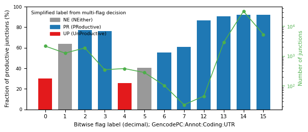

Number of junctions and ground-truth productive fraction, by the full 4-bit junction flag, at the reference condition (comprehensive Gencode, 20 GB, uniform coverage).

```python
flagcomb = pd.read_csv(OUTPUT / "FigS4C_FlagCombinationProductiveFraction.tsv.gz", sep="\t")
CATEGORY_COL = {"NE": "#999999", "PR": "#1f78b4", "UP": "#e31a1c"}

fig, ax1 = plt.subplots(figsize=(6.4, 2.8))
x = np.arange(len(flagcomb))
ax1.bar(x, flagcomb.Frac_Productive * 100, width=0.7,
       color=[CATEGORY_COL[c] for c in flagcomb.Category])
ax1.set_ylim(0, 100)
ax1.set_ylabel("Fraction of productive junctions (%)", fontsize=8)
ax1.set_xticks(x)
ax1.set_xticklabels(flagcomb.DecimalFlag, fontsize=8)
ax1.set_xlabel("Bitwise flag label (decimal); GencodePC:Annot:Coding:UTR", fontsize=8)
ax1.tick_params(axis="y", labelsize=7)
ax1.spines["top"].set_visible(False)
ax1.legend(handles=[plt.Rectangle((0, 0), 1, 1, color=c) for c in CATEGORY_COL.values()],
          labels=[f"{cat} ({lab})" for cat, lab in
                  [("NE", "NEither"), ("PR", "PRoductive"), ("UP", "UnProductive")]],
          title="Simplified label from multi-flag decision", title_fontsize=7, fontsize=7,
          loc="upper left", frameon=False)

ax2 = ax1.twinx()
ax2.plot(x, flagcomb.Total, marker="o", color="#4daf4a", lw=1.2, ms=4)
ax2.set_yscale("log")
ax2.set_ylabel("Number of junctions", fontsize=8, color="#4daf4a")
ax2.tick_params(axis="y", labelsize=7, colors="#4daf4a")
fig.tight_layout()
plt.show()
```

```python
record_source("FigS4C", flagcomb)
```

Unannotated junctions (decimal flags 0-3, `GencodePC=Annot=0`) split close to evenly between productive and unproductive, while fully annotated ones (12-15) are overwhelmingly productive — the imbalance an annotation-blind classifier has to overcome.

## FigS4D — classification accuracy by method and junction subclass

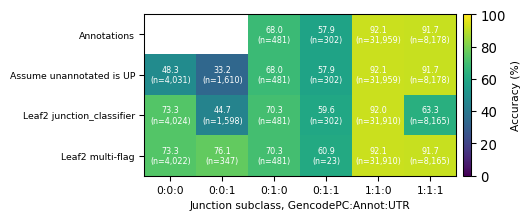

Classification accuracy (%) by method and junction subclass at the reference condition. Each cell also gives the number of junctions classified. P-values: two-sided chi-square on the shipped aggregate correct/incorrect counts (an unpaired approximation to the manuscript’s per-junction paired test; see FOOTNOTES.md).

```
0:0:0: Assume unannotated is UP vs Leaf2 multi-flag, chi-square P = 4.3e-116
0:0:1: Leaf2 junction_classifier vs Leaf2 multi-flag, chi-square P = 5.4e-26
```

```python
ref_d = pd.concat([
    master[master.GTF.eq("Comprehensive_Gencode") & master.Coverage_GB.eq(20)
           & master.Coverage_bias_Beta_params.eq("alpha_1_beta_1")],
    master[master.GTF.eq("Comprehensive_Gencode") & master.Coverage_GB.isna()],
], ignore_index=True)
ref_d = ref_d[ref_d.Subclass.isin(SUBCLASS_LEVELS[:-1])].copy()
ref_d["n_classified"] = ref_d[["TP", "TN", "FP", "FN"]].sum(axis=1)
ref_d["Accuracy"] = np.where(ref_d.n_classified > 0,
                             (ref_d.TP + ref_d.TN) / ref_d.n_classified, np.nan)

METHOD_D_ORDER = ["Annotations", "Assume unannotated is UP",
                  "Leaf2 junction_classifier", "Leaf2 multi-flag"]
piv_acc = (ref_d.pivot(index="Method", columns="Subclass", values="Accuracy")
           .reindex(index=METHOD_D_ORDER, columns=SUBCLASS_LEVELS[:-1]) * 100)
piv_n = (ref_d.pivot(index="Method", columns="Subclass", values="n_classified")
         .reindex(index=METHOD_D_ORDER, columns=SUBCLASS_LEVELS[:-1]))

fig, ax = plt.subplots(figsize=(5.6, 2.4))
im = ax.imshow(np.ma.masked_invalid(piv_acc.to_numpy()), cmap="viridis",
              vmin=0, vmax=100, aspect="auto")
for i in range(piv_acc.shape[0]):
    for j in range(piv_acc.shape[1]):
        v, n = piv_acc.iloc[i, j], piv_n.iloc[i, j]
        lab = "" if np.isnan(v) else f"{v:.1f}\n(n={int(n):,})"
        ax.text(j, i, lab, ha="center", va="center", fontsize=6, color="white")
ax.set_xticks(range(len(SUBCLASS_LEVELS[:-1])))
ax.set_xticklabels(SUBCLASS_LEVELS[:-1], fontsize=8)
ax.set_yticks(range(len(METHOD_D_ORDER)))
ax.set_yticklabels(METHOD_D_ORDER, fontsize=7)
ax.set_xlabel("Junction subclass, GencodePC:Annot:UTR", fontsize=8)
fig.colorbar(im, ax=ax, fraction=0.04, pad=0.02).set_label("Accuracy (%)", fontsize=8)
fig.tight_layout()
plt.show()


def correct_incorrect(method, subclass):
    r = ref_d[(ref_d.Method == method) & (ref_d.Subclass == subclass)].iloc[0]
    return r.TP + r.TN, r.FP + r.FN


from scipy.stats import chi2_contingency
for m1, m2, sub in [("Assume unannotated is UP", "Leaf2 multi-flag", "0:0:0"),
                    ("Leaf2 junction_classifier", "Leaf2 multi-flag", "0:0:1")]:
    table = [correct_incorrect(m1, sub), correct_incorrect(m2, sub)]
    _, p, _, _ = chi2_contingency(table)
    print(f"{sub}: {m1} vs {m2}, chi-square P = {p:.2g}")
```

```python
record_source("FigS4D", ref_d[["Method", "Subclass", "n_classified", "Accuracy"]])
```

## Unannotated junctions: the case the annotation cannot reach

This is the panel that motivates the whole exercise. It restricts to **completely unannotated junctions** (`0:0:0` and `0:0:1` pooled), against comprehensive Gencode, and asks how well leafcutter2’s own verdict recovers their productivity status.

An annotation-based method scores zero here by construction — it has nothing to say about a junction it has never seen. So the y-axis is not “is the classifier good”, it is “can anything be recovered at all”.

Each point is one (depth × bias) condition: colour is the fragment-bias condition, size is sequencing depth. The dashed diagonal is chance; the dotted line is the ceiling set by leafcutter2’s own abstentions.

```
5,641 ground-truth labels in unannotated junctions (44.0% unproductive)
leafcutter2 returns NE for 452 of 2,483 unproductive ones -> recall ceiling 81.8%
```

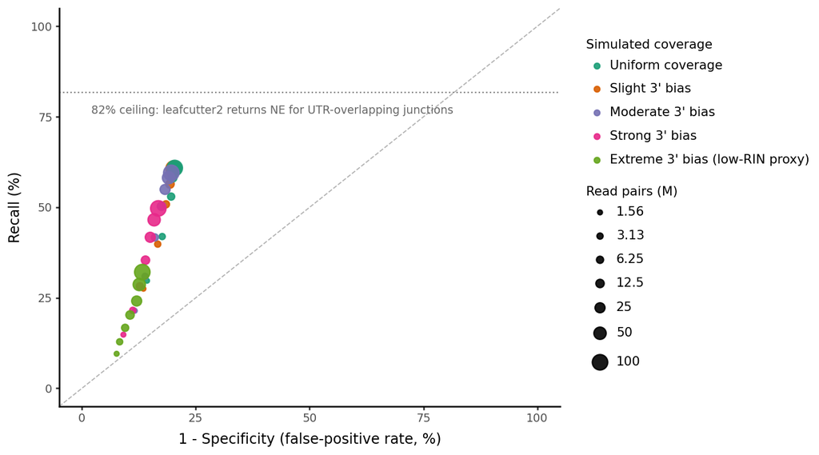

Recall and false-positive rate for completely unannotated junctions (subclasses 0:0:0 and 0:0:1 pooled), comprehensive Gencode annotation, leafcutter2 multi-flag verdict. Colour: fragment-bias condition. Size: sequencing depth. Dashed line: chance. Dotted line: the recall ceiling imposed by leafcutter2 declining to classify UTR-overlapping junctions.

```python
BIAS_COLORS = {
    "alpha_1_beta_1": "#1b9e77",
    "alpha_1.5_beta_1": "#d95f02",
    "alpha_2.5_beta_1": "#7570b3",
    "alpha_4.5_beta_1": "#e7298a",
    "alpha_8.5_beta_1": "#66a61e",
}
BIAS_LABELS = {
    "alpha_1_beta_1": "Uniform coverage",
    "alpha_1.5_beta_1": "Slight 3' bias",
    "alpha_2.5_beta_1": "Moderate 3' bias",
    "alpha_4.5_beta_1": "Strong 3' bias",
    "alpha_8.5_beta_1": "Extreme 3' bias (low-RIN proxy)",
}
# Coverage_GB -> read pairs in millions, so the legend is in units people think in
COV_BREAKS = [0.3125, 0.625, 1.25, 2.5, 5, 10, 20]
COV_LABELS = ["1.56", "3.13", "6.25", "12.5", "25", "50", "100"]

# Pool the two unannotated subclasses, then recompute metrics on the pooled counts --
# these are ratios, so they cannot simply be averaged.
unannot = (
    metrics[metrics.Subclass.astype(str).isin(["0:0:0", "0:0:1"])]
    .groupby(["GTF", "Method", "Coverage_bias_Beta_params", "Coverage_GB"],
             dropna=False)[COUNT_COLS]
    .sum()
    .reset_index()
)
unannot["Recall_v2"] = unannot.TP / (
    unannot.TP + unannot.FN + unannot.UP_NE_ByMethod + unannot.UP_NotDetected)
unannot["FPR_v2"] = unannot.FP / (
    unannot.FP + unannot.TN + unannot.PR_NE_ByMethod + unannot.PR_NotDetected)

sr = unannot[
    unannot.GTF.eq("Comprehensive_Gencode")
    & unannot.Coverage_GB.notna()
    & unannot.Method.eq("Leaf2 multi-flag")
].copy()
# Order the factor so the legend reads uniform -> extreme; alphabetical would put
# alpha_1.5 before alpha_1.
sr["Coverage_bias_Beta_params"] = pd.Categorical(
    sr.Coverage_bias_Beta_params, categories=list(BIAS_COLORS), ordered=True)

# The ceiling is set by the junctions leafcutter2 returns NE for by design: those
# overlapping an annotated UTR, where its coding flag carries no information.
ref = unannot[
    unannot.GTF.eq("Comprehensive_Gencode")
    & unannot.Method.eq("Leaf2 multi-flag")
    & unannot.Coverage_GB.eq(20)
    & unannot.Coverage_bias_Beta_params.eq("alpha_1_beta_1")
].iloc[0]
n_up = ref.TP + ref.FN + ref.UP_NE_ByMethod + ref.UP_NotDetected
n_pr = ref.FP + ref.TN + ref.PR_NE_ByMethod + ref.PR_NotDetected
ceiling = 100 * (n_up - ref.UP_NE_ByMethod) / n_up

print(f"{int(n_up + n_pr):,} ground-truth labels in unannotated junctions "
      f"({100 * n_up / (n_up + n_pr):.1f}% unproductive)")
print(f"leafcutter2 returns NE for {int(ref.UP_NE_ByMethod):,} of {int(n_up):,} "
      f"unproductive ones -> recall ceiling {ceiling:.1f}%")

p_unannot = (
    ggplot(sr, aes("FPR_v2*100", "Recall_v2*100"))
    + geom_abline(slope=1, intercept=0, linetype="dashed", color="#b3b3b3", size=0.4)
    + geom_hline(yintercept=ceiling, linetype="dotted", color="#808080", size=0.5)
    + geom_point(aes(color="Coverage_bias_Beta_params", size="Coverage_GB"), alpha=0.9)
    + annotate(
        "text", x=2, y=ceiling - 3.5,
        label=f"{ceiling:.0f}% ceiling: leafcutter2 returns NE for UTR-overlapping junctions",
        ha="left", va="top", size=7, color="#666666")
    + scale_color_manual(values=BIAS_COLORS, labels=BIAS_LABELS,
                         name="Simulated coverage")
    + scale_size_continuous(name="Read pairs (M)", range=(1.2, 5),
                            breaks=COV_BREAKS, labels=COV_LABELS)
    + scale_x_continuous(breaks=[0, 25, 50, 75, 100])
    + scale_y_continuous(breaks=[0, 25, 50, 75, 100])
    + coord_cartesian(xlim=(0, 100), ylim=(0, 100))
    + labs(x="1 - Specificity (false-positive rate, %)", y="Recall (%)")
    + theme_classic(base_size=9)
    + theme(
        # Legend outside the panel: at the original 2x2in panel size it sat on the data.
        legend_position="right",
        legend_box="vertical",
        legend_text=element_text(size=8),
        legend_title=element_text(size=8),
        panel_background=element_rect(fill="white", color="black", size=0.4),
        figure_size=(7.2, 4.0),
    )
)
p_unannot
```

```python
record_source("Fig1F", sr[["Coverage_bias_Beta_params", "Coverage_GB", "FPR_v2", "Recall_v2"]])
```

That leaves the gap at the top. At 20 GB with uniform coverage only 0.2% of unproductive junctions go undetected, yet recall is 60.9% against an 82% ceiling — so about **21 points are genuine misclassification**: junctions seen, called, and called productive when they are not. The remaining 18 points to 100% are leafcutter2’s abstentions, which it returns for junctions overlapping an annotated UTR because outside the CDS its coding flag carries no information about productivity. `Recall_v2` charges those as misses, which is why they appear as a ceiling rather than being quietly excluded.

## Does a more comprehensive annotation help?

Held at the best condition — 20 GB, uniform coverage — this crosses all four methods against all three annotation sets, for every subclass. Rows are metrics, columns are subclasses.

The question it answers: if a classifier is only as good as the annotation you give it, then moving from minimal (MANE) to comprehensive (Gencode) should lift performance across the board. It does not, and the bottom row shows why.

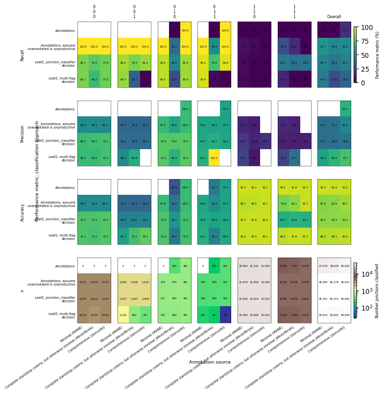

Performance by annotation comprehensiveness at 20 GB with uniform coverage. Rows: Recall, Precision, Accuracy (viridis, 0-100%) and number of junctions classified (terrain, log scale). Columns: junction subclass GencodePC:Annot:UTR, plus the overall pool. Within each panel, rows are the four methods and columns the three annotation sets.

```python
fig6_dat = pd.concat([
    metrics[metrics.Coverage_GB.eq(20)
            & metrics.Coverage_bias_Beta_params.eq("alpha_1_beta_1")],
    metrics[metrics.Coverage_GB.isna()],
], ignore_index=True)

gtf_order = [GTF_LABELS[g] for g in GTF_LEVELS]
metric_order = ["Recall", "Precision", "Accuracy", "n"]

fig, axes = plt.subplots(len(metric_order), len(SUBCLASS_LEVELS),
                         figsize=(7.5, 8.3), constrained_layout=True)
perf_cmap, perf_norm = plt.cm.viridis, mpl.colors.Normalize(vmin=0, vmax=100)
n_vals = fig6_dat.n_classified.where(fig6_dat.n_classified > 0)
n_cmap = plt.cm.terrain
n_norm = LogNorm(vmin=max(1, float(n_vals.min(skipna=True))),
                 vmax=float(n_vals.max(skipna=True)))

for cidx, subclass in enumerate(SUBCLASS_LEVELS):
    sub = fig6_dat[fig6_dat.Subclass.astype(str).eq(subclass)].copy()
    sub["GTF_label"] = pd.Categorical(
        sub.GTF.map(GTF_LABELS), categories=gtf_order, ordered=True)
    mats = {
        "Recall": sub.pivot(index="Method_long", columns="GTF_label",
                            values="Recall_v1") * 100,
        "Precision": sub.pivot(index="Method_long", columns="GTF_label",
                               values="Precision") * 100,
        "Accuracy": sub.pivot(index="Method_long", columns="GTF_label",
                              values="Accuracy") * 100,
        "n": sub.pivot(index="Method_long", columns="GTF_label",
                       values="n_classified").astype(float),
    }
    for ridx, name in enumerate(metric_order):
        ax = axes[ridx, cidx]
        vals = mats[name].reindex(index=METHOD_LONG_LEVELS, columns=gtf_order).to_numpy()
        ax.imshow(np.ma.masked_invalid(vals),
                  cmap=perf_cmap if name != "n" else n_cmap,
                  norm=perf_norm if name != "n" else n_norm, aspect="auto")
        for i in range(vals.shape[0]):
            for j in range(vals.shape[1]):
                v = vals[i, j]
                if np.isnan(v):
                    lab = ""
                elif name == "n":
                    lab = f"{int(round(v)):,}"
                else:
                    lab = f"{v:.1f}"
                ax.text(j, i, lab, ha="center", va="center", fontsize=4)
        ax.set_xticks(range(len(gtf_order)))
        ax.set_yticks(range(len(METHOD_LONG_LEVELS)))
        if ridx == len(metric_order) - 1:
            ax.set_xticklabels([g.replace("\n", " ") for g in gtf_order],
                               fontsize=5, rotation=35, ha="right")
        else:
            ax.set_xticklabels([])
        if cidx == 0:
            ax.set_yticklabels(METHOD_LONG_LEVELS, fontsize=5)
            ax.set_ylabel(name, fontsize=6)
        else:
            ax.set_yticklabels([])
        if ridx == 0:
            ax.set_title(subclass if subclass == "Overall"
                         else subclass.replace(":", "\n"), fontsize=6)
        for sp in ax.spines.values():
            sp.set_visible(True)
            sp.set_linewidth(0.4)
        ax.tick_params(length=0)

for row, cmap, cnorm, clabel in [
    (0, perf_cmap, perf_norm, "Performance metric (%)"),
    (-1, n_cmap, n_norm, "Number junctions classified"),
]:
    cax = inset_axes(axes[row, -1], width="8%", height="85%", loc="center left",
                     bbox_to_anchor=(1.08, 0.0, 1, 1),
                     bbox_transform=axes[row, -1].transAxes, borderpad=0)
    mpl.colorbar.ColorbarBase(
        cax, cmap=cmap, norm=cnorm, orientation="vertical").set_label(clabel, fontsize=6)

fig.supxlabel("Annotation source", fontsize=7)
fig.supylabel("Performance metric, classification approach", fontsize=7)
plt.show()
```

The bottom `n` row is the necessary companion: a high percentage over a handful of junctions is not the same claim as a high percentage over thousands, and reading the upper rows without it is how these comparisons get overstated.

## Is the simulated coverage bias realistic?

A sanity check on the simulation itself, and the one figure here that does not come from the confusion table. If the `Beta(alpha, 1)` fragment-bias grid did not span the 3’ bias seen in real degraded RNA, the depth-and-bias axes above would not mean much.

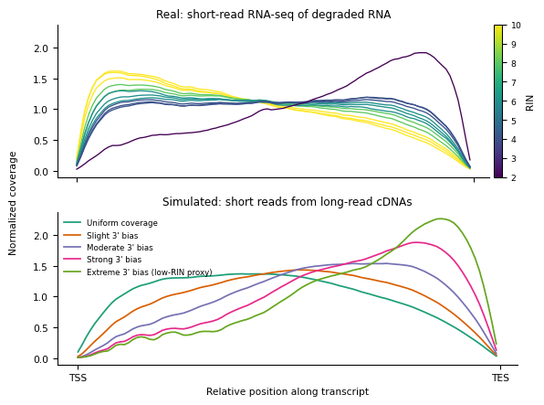

Metagene coverage, real degraded RNA versus simulation. Top: 12 public libraries with measured RIN 2-10 (Sigurgeirsson et al., SRP023548), coloured by RIN. Bottom: the 5 simulated fragment-bias conditions. Each library is normalised by its own mean coverage, so the panels compare profile shape rather than depth.

```python
def load_metagene(path):
    long = pd.read_csv(path, sep="\t").melt(
        id_vars="sample", var_name="bin", value_name="Coverage")
    long["bin"] = long["bin"].str.removeprefix("bin_").astype(int)
    long["Coverage"] = long.Coverage / long.groupby("sample").Coverage.transform("mean")
    return long

rin = load_metagene(OUTPUT / "Metagene" / "RIN_metagene_avg.txt")
sim = load_metagene(OUTPUT / "Metagene" / "Simulated_metagene_avg.txt")
meta = pd.read_csv(PROJECT / "code" / "config" / "RIN_Control_Samples.tsv", sep="\t")
rin = rin.merge(meta[["sample", "RIN"]], on="sample", how="left")
if rin.RIN.isna().any():
    raise ValueError(f"no RIN for: {sorted(rin.loc[rin.RIN.isna(), 'sample'].unique())}")

fig, axes = plt.subplots(2, 1, figsize=(160 * MM, 120 * MM), sharex=True, sharey=True)

norm = mpl.colors.Normalize(vmin=rin.RIN.min(), vmax=rin.RIN.max())
for _, g in rin.groupby("sample"):
    g = g.sort_values("bin")
    axes[0].plot(g.bin, g.Coverage, lw=1.0, color=plt.cm.viridis(norm(g.RIN.iloc[0])))
axes[0].set_title("Real: short-read RNA-seq of degraded RNA", fontsize=9)
cb = fig.colorbar(mpl.cm.ScalarMappable(norm=norm, cmap=plt.cm.viridis),
                  ax=axes[0], pad=0.01, fraction=0.05)
cb.set_label("RIN", fontsize=8)
cb.ax.tick_params(labelsize=7)

for name, color in zip(BIAS_COLORS, plt.cm.Dark2.colors):
    g = sim[sim["sample"].eq(name)].sort_values("bin")
    if not g.empty:
        axes[1].plot(g.bin, g.Coverage, lw=1.3, color=color, label=BIAS_LABELS[name])
axes[1].set_title("Simulated: short reads from long-read cDNAs", fontsize=9)
axes[1].legend(fontsize=6.5, frameon=False, loc="upper left")

for ax in axes:
    ax.set_xticks([0, 100])
    ax.set_xticklabels(["TSS", "TES"], fontsize=8)
    ax.tick_params(axis="y", labelsize=8)
    ax.spines[["top", "right"]].set_visible(False)
axes[1].set_xlabel("Relative position along transcript", fontsize=8)
fig.supylabel("Normalized coverage", fontsize=8)
fig.tight_layout()
plt.show()
```

The real libraries fan out with RIN: intact ones (yellow) are flat-to-5’-weighted, and the most degraded (dark purple, RIN 2) piles coverage at the 3’ end. The simulated grid reproduces that span, with `alpha_8.5` reaching past the worst real sample. So the extreme end of the bias axis is not an extrapolation — it brackets real data.

## Source data

One spreadsheet, one tab per panel (main-text and supplemental together), holding the exact table each panel above plots.

```python
SOURCE_DATA_XLSX = PROJECT / "analysis" / "SourceData_SimulationBenchmark.xlsx"
with pd.ExcelWriter(SOURCE_DATA_XLSX, engine="openpyxl") as xl:
    for panel, df in SOURCE_DATA.items():
        df.to_excel(xl, sheet_name=panel[:31], index=False)
print(f"{len(SOURCE_DATA)} tabs -> {SOURCE_DATA_XLSX.name} "
      f"({SOURCE_DATA_XLSX.stat().st_size / 1024:.0f} KB)")
pd.DataFrame({"panel": list(SOURCE_DATA), "n_rows": [len(d) for d in SOURCE_DATA.values()]})
```

```
3 tabs -> SourceData_SimulationBenchmark.xlsx (9 KB)
```

|  | panel | n_rows |
| --- | --- | --- |
| 0 | FigS4C | 12 |
| 1 | FigS4D | 24 |
| 2 | Fig1F | 35 |

Details of provenance, the leafcutter2 version difference, and what this bundle does not reproduce are in FOOTNOTES.md.